# study1 preprocessing

anonymous

2024-12-10

```r
knit_by_pkgdown <- !is.null(knitr::opts_chunk$get("fig.retina"))
knitr::opts_chunk$set(
  warning = TRUE, # show warnings during codebook generation
  message = TRUE, # show messages during codebook generation
  error = TRUE, # do not interrupt codebook generation in case of errors,
                # TRUE is usually better for debugging
  echo = TRUE  # show R code
)

library(pacman)
pacman::p_load(tidyverse, here, codebook)
ggplot2::theme_set(ggplot2::theme_bw())
```

# 1 Read data

```r
base_path <- here("code", "study1")
data_path <- paste0(base_path, "/data/study1_data_raw.csv")
d <- read_csv(data_path)
codebook::codebook(d)
```

### 1.0.1 Metadata

#### 1.0.1.1 Description

**Dataset name**: d

The dataset has N=1200 rows and 40 columns. 0 rows have no missing values on any column.

**Metadata for search engines**

- **Date published**: 2025-02-02

| x |
| --- |
| subject_id |
| success |
| timeout |
| failed_images |
| failed_audio |
| failed_video |
| trial_type |
| trial_index |
| plugin_version |
| time_elapsed |
| trial_id |
| rt |
| stimulus |
| response |
| view_history |
| init_locations |
| moves |
| final_locations |
| 0 |
| 1 |
| 2 |
| 3 |
| 4 |
| 5 |
| 6 |
| 7 |
| 8 |
| 9 |
| 10 |
| 11 |
| 12 |
| 13 |
| 14 |
| question_order |
| 15 |
| feedback |
| age |
| ethnicity |
| gender |
| race |

## 1.1 Variables

### 1.1.1 subject_id

#### 1.1.1.1 Distribution

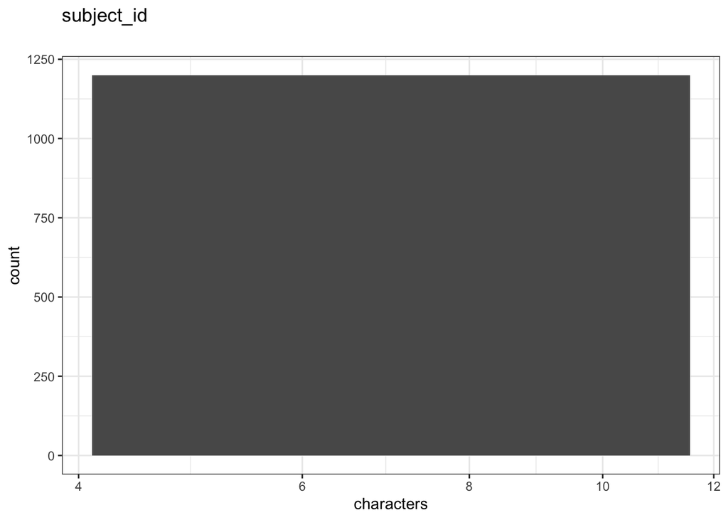

Distribution of values for subject_id

0 missing values.

#### 1.1.1.2 Summary statistics

| name | data_type | n_missing | complete_rate | n_unique | empty | min | max | whitespace | label |
| --- | --- | --- | --- | --- | --- | --- | --- | --- | --- |
| subject_id | character | 0 | 1 | 50 | 0 | 7 | 7 | 0 | NA |

### 1.1.2 success

#### 1.1.2.1 Distribution

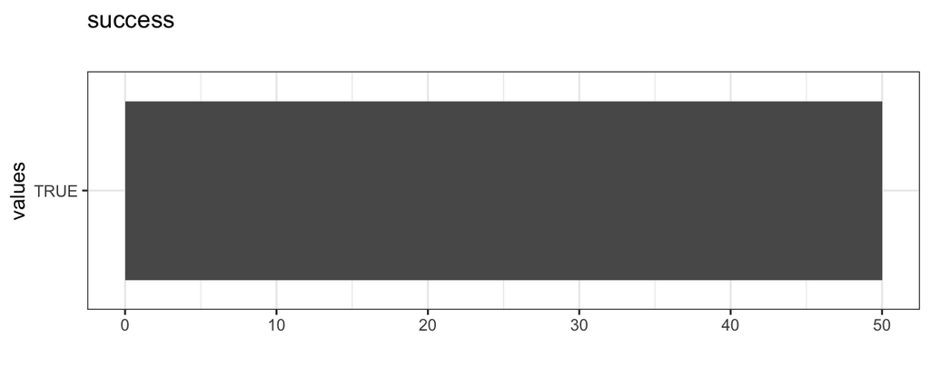

Distribution of values for success

1150 missing values.

#### 1.1.2.2 Summary statistics

| name | data_type | n_missing | complete_rate | count | mean | label |
| --- | --- | --- | --- | --- | --- | --- |
| success | logical | 1150 | 0.0416667 | TRU: 50 | 1 | NA |

### 1.1.3 timeout

#### 1.1.3.1 Distribution

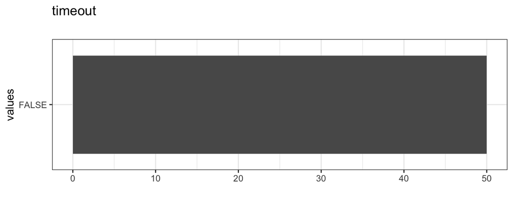

Distribution of values for timeout

1150 missing values.

#### 1.1.3.2 Summary statistics

| name | data_type | n_missing | complete_rate | count | mean | label |
| --- | --- | --- | --- | --- | --- | --- |
| timeout | logical | 1150 | 0.0416667 | FAL: 50 | 0 | NA |

### 1.1.4 failed_images

#### 1.1.4.1 Distribution

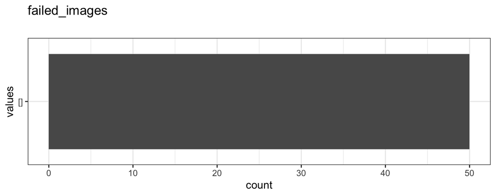

Distribution of values for failed_images

1150 missing values.

#### 1.1.4.2 Summary statistics

| name | data_type | n_missing | complete_rate | n_unique | empty | min | max | whitespace | label |
| --- | --- | --- | --- | --- | --- | --- | --- | --- | --- |
| failed_images | character | 1150 | 0.0416667 | 1 | 0 | 2 | 2 | 0 | NA |

### 1.1.5 failed_audio

#### 1.1.5.1 Distribution

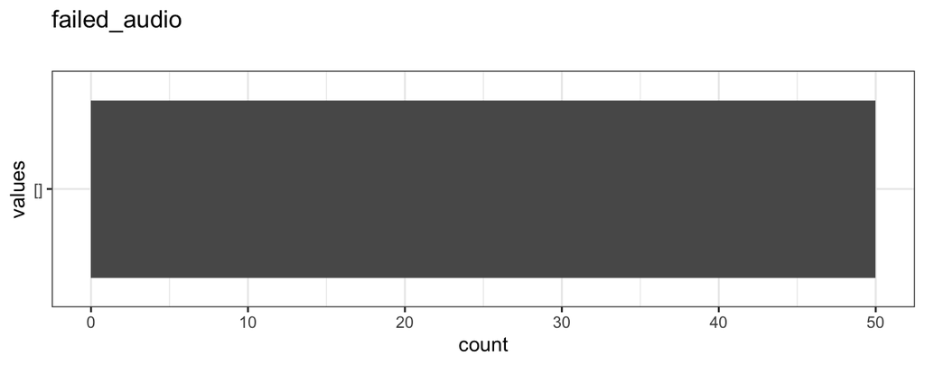

Distribution of values for failed_audio

1150 missing values.

#### 1.1.5.2 Summary statistics

| name | data_type | n_missing | complete_rate | n_unique | empty | min | max | whitespace | label |
| --- | --- | --- | --- | --- | --- | --- | --- | --- | --- |
| failed_audio | character | 1150 | 0.0416667 | 1 | 0 | 2 | 2 | 0 | NA |

### 1.1.6 failed_video

#### 1.1.6.1 Distribution

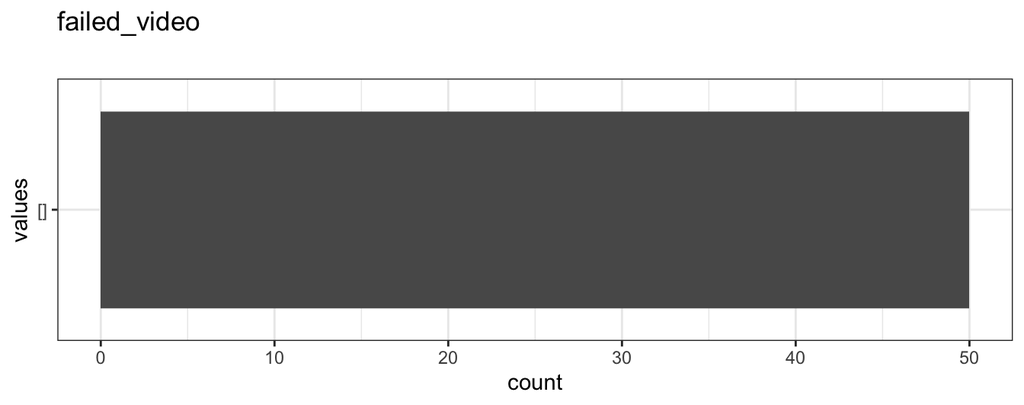

Distribution of values for failed_video

1150 missing values.

#### 1.1.6.2 Summary statistics

| name | data_type | n_missing | complete_rate | n_unique | empty | min | max | whitespace | label |
| --- | --- | --- | --- | --- | --- | --- | --- | --- | --- |
| failed_video | character | 1150 | 0.0416667 | 1 | 0 | 2 | 2 | 0 | NA |

### 1.1.7 trial_type

#### 1.1.7.1 Distribution

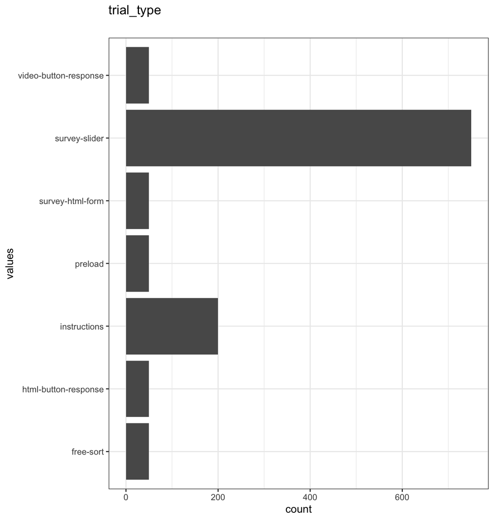

Distribution of values for trial_type

0 missing values.

#### 1.1.7.2 Summary statistics

| name | data_type | n_missing | complete_rate | n_unique | empty | min | max | whitespace | label |
| --- | --- | --- | --- | --- | --- | --- | --- | --- | --- |
| trial_type | character | 0 | 1 | 7 | 0 | 7 | 21 | 0 | NA |

### 1.1.8 trial_index

#### 1.1.8.1 Distribution

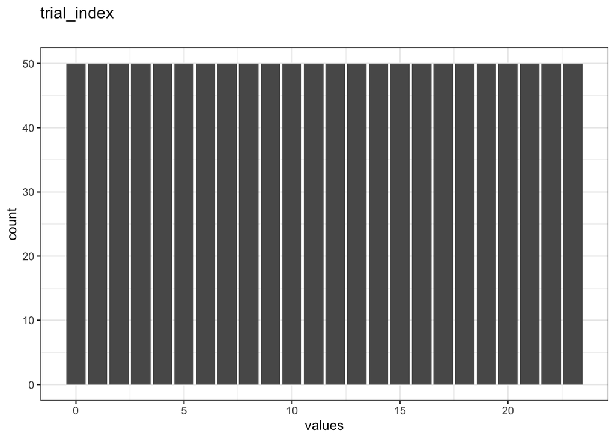

Distribution of values for trial_index

0 missing values.

#### 1.1.8.2 Summary statistics

| name | data_type | n_missing | complete_rate | min | median | max | mean | sd | hist | label |
| --- | --- | --- | --- | --- | --- | --- | --- | --- | --- | --- |
| trial_index | numeric | 0 | 1 | 0 | 12 | 23 | 11.5 | 6.925073 | ▇▇▆▇▇ | NA |

### 1.1.9 plugin_version

#### 1.1.9.1 Distribution

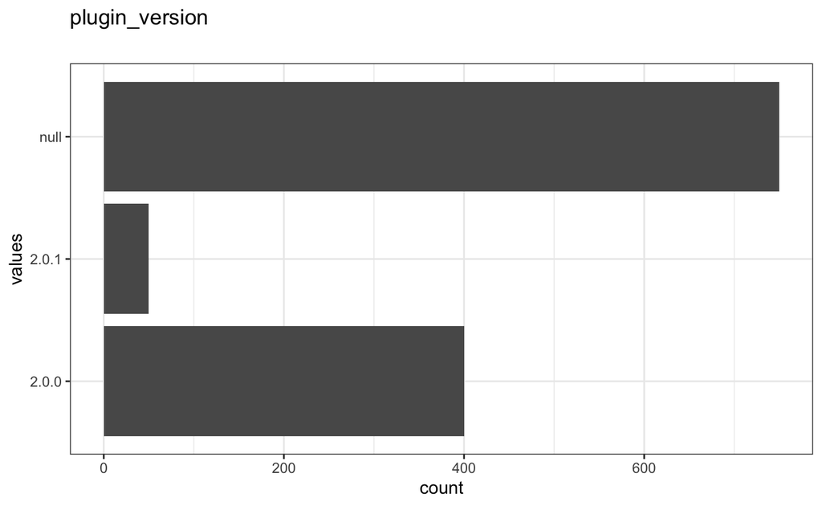

Distribution of values for plugin_version

0 missing values.

#### 1.1.9.2 Summary statistics

| name | data_type | n_missing | complete_rate | n_unique | empty | min | max | whitespace | label |
| --- | --- | --- | --- | --- | --- | --- | --- | --- | --- |
| plugin_version | character | 0 | 1 | 3 | 0 | 4 | 5 | 0 | NA |

### 1.1.10 time_elapsed

#### 1.1.10.1 Distribution

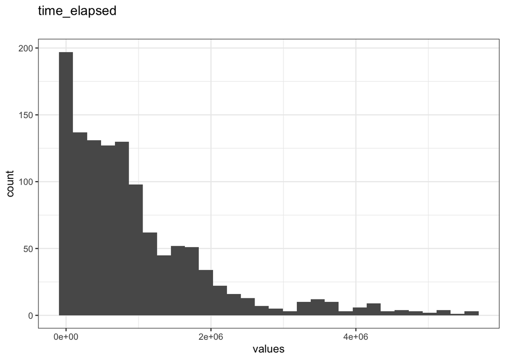

Distribution of values for time_elapsed

0 missing values.

#### 1.1.10.2 Summary statistics

| name | data_type | n_missing | complete_rate | min | median | max | mean | sd | hist | label |
| --- | --- | --- | --- | --- | --- | --- | --- | --- | --- | --- |
| time_elapsed | numeric | 0 | 1 | 154 | 684924 | 5596441 | 965786.4 | 1025307 | ▇▂▁▁▁ | NA |

### 1.1.11 trial_id

#### 1.1.11.1 Distribution

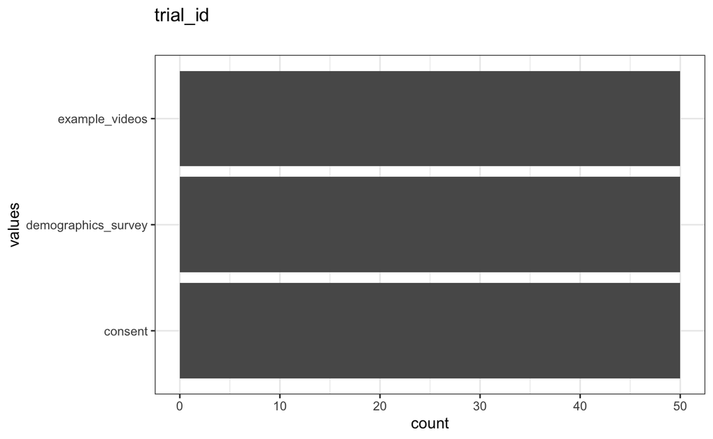

Distribution of values for trial_id

1050 missing values.

#### 1.1.11.2 Summary statistics

| name | data_type | n_missing | complete_rate | n_unique | empty | min | max | whitespace | label |
| --- | --- | --- | --- | --- | --- | --- | --- | --- | --- |
| trial_id | character | 1050 | 0.125 | 3 | 0 | 7 | 19 | 0 | NA |

### 1.1.12 rt

#### 1.1.12.1 Distribution

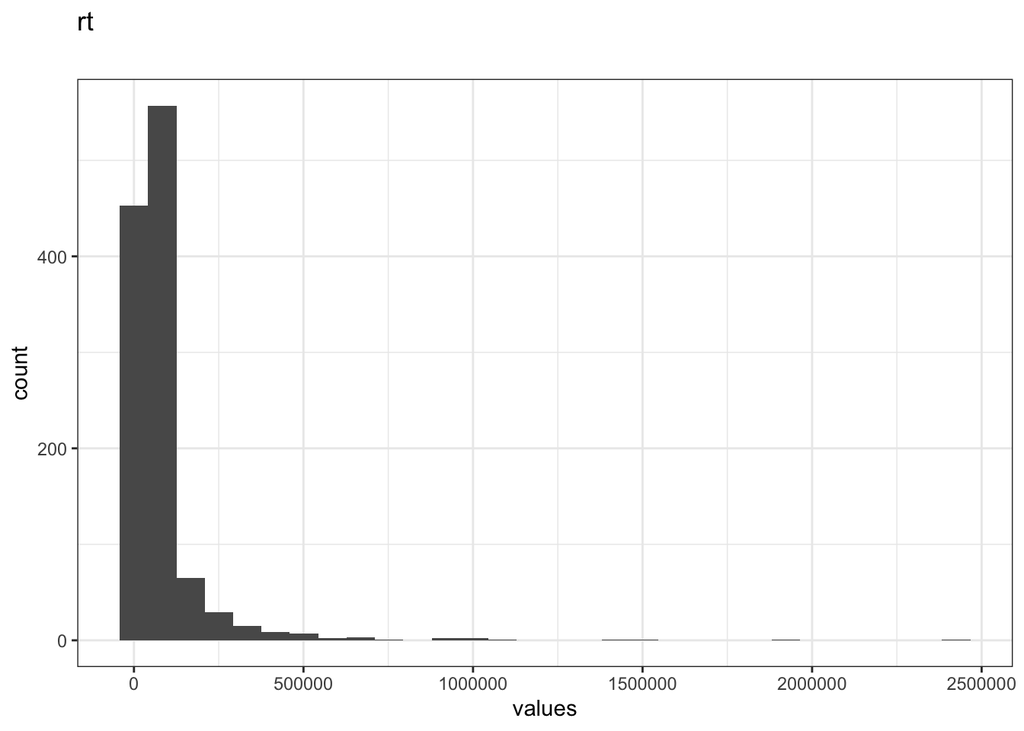

Distribution of values for rt

50 missing values.

#### 1.1.12.2 Summary statistics

| name | data_type | n_missing | complete_rate | min | median | max | mean | sd | hist | label |
| --- | --- | --- | --- | --- | --- | --- | --- | --- | --- | --- |
| rt | numeric | 50 | 0.9583333 | 906 | 51539 | 2425768 | 83171.52 | 147934.4 | ▇▁▁▁▁ | NA |

### 1.1.13 stimulus

#### 1.1.13.1 Distribution

[figure not shown]

Distribution of values for stimulus

1100 missing values.

#### 1.1.13.2 Summary statistics

| name | data_type | n_missing | complete_rate | n_unique | empty | min | max | whitespace | label |
| --- | --- | --- | --- | --- | --- | --- | --- | --- | --- |
| stimulus | character | 1100 | 0.0833333 | 2 | 0 | 35 | 1959 | 0 | NA |

### 1.1.14 response

#### 1.1.14.1 Distribution

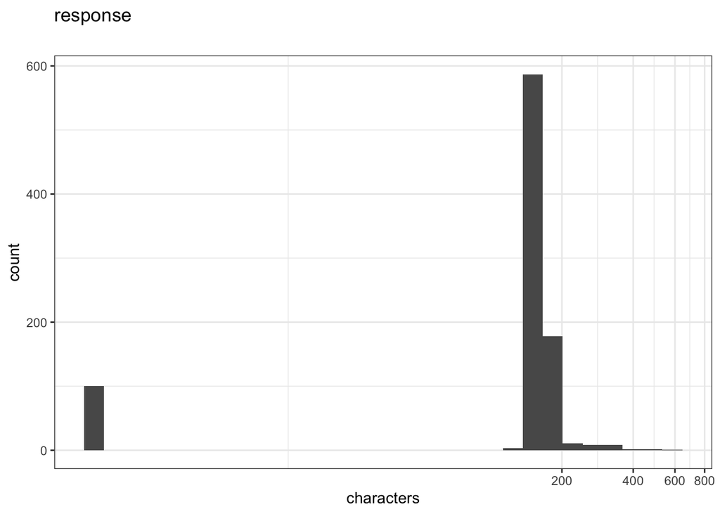

Distribution of values for response

300 missing values.

#### 1.1.14.2 Summary statistics

| name | data_type | n_missing | complete_rate | n_unique | empty | min | max | whitespace | label |
| --- | --- | --- | --- | --- | --- | --- | --- | --- | --- |
| response | character | 300 | 0.75 | 801 | 0 | 1 | 540 | 0 | NA |

### 1.1.15 view_history

#### 1.1.15.1 Distribution

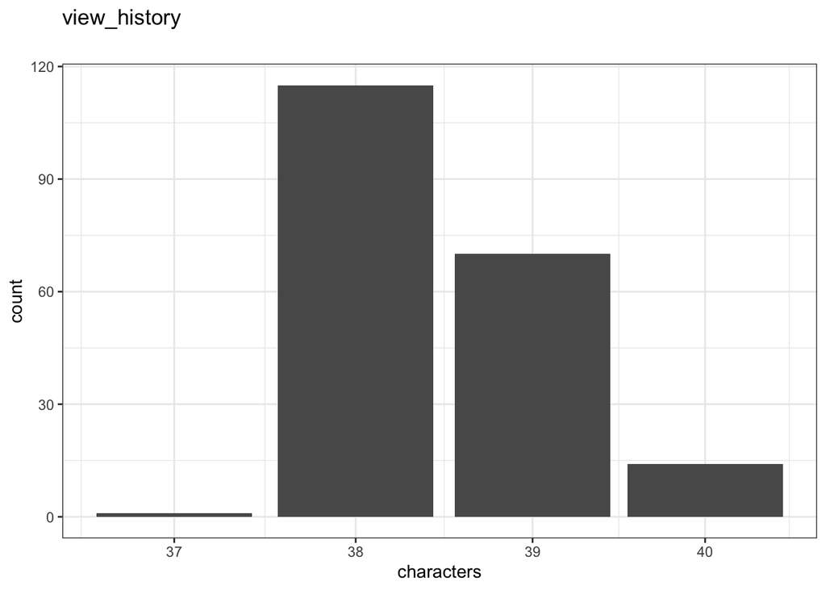

Distribution of values for view_history

1000 missing values.

#### 1.1.15.2 Summary statistics

| name | data_type | n_missing | complete_rate | n_unique | empty | min | max | whitespace | label |
| --- | --- | --- | --- | --- | --- | --- | --- | --- | --- |
| view_history | character | 1000 | 0.1666667 | 198 | 0 | 37 | 40 | 0 | NA |

### 1.1.16 init_locations

#### 1.1.16.1 Distribution

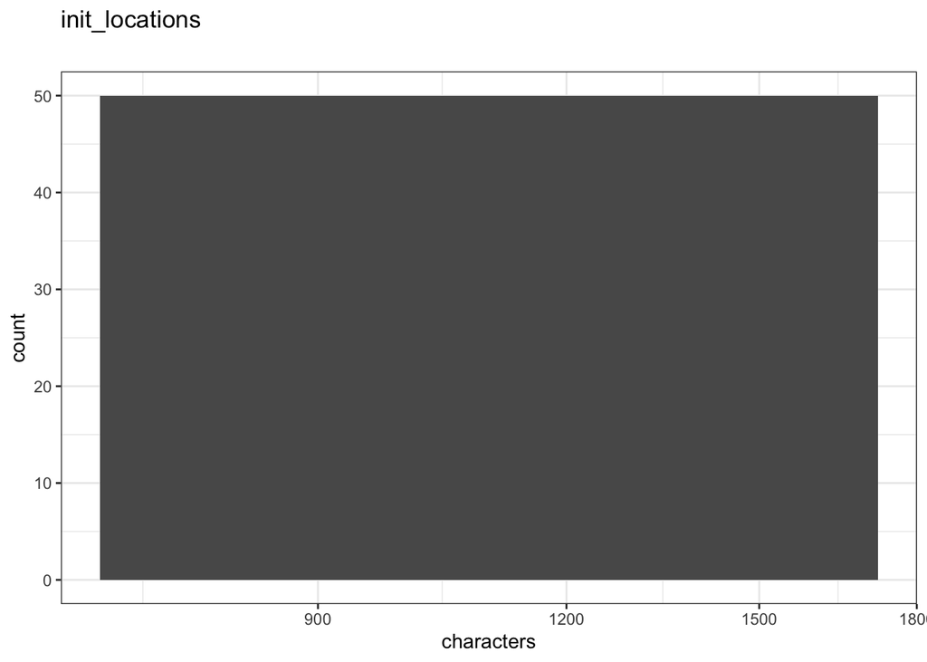

Distribution of values for init_locations

1150 missing values.

#### 1.1.16.2 Summary statistics

| name | data_type | n_missing | complete_rate | n_unique | empty | min | max | whitespace | label |
| --- | --- | --- | --- | --- | --- | --- | --- | --- | --- |
| init_locations | character | 1150 | 0.0416667 | 50 | 0 | 1097 | 1097 | 0 | NA |

### 1.1.17 moves

#### 1.1.17.1 Distribution

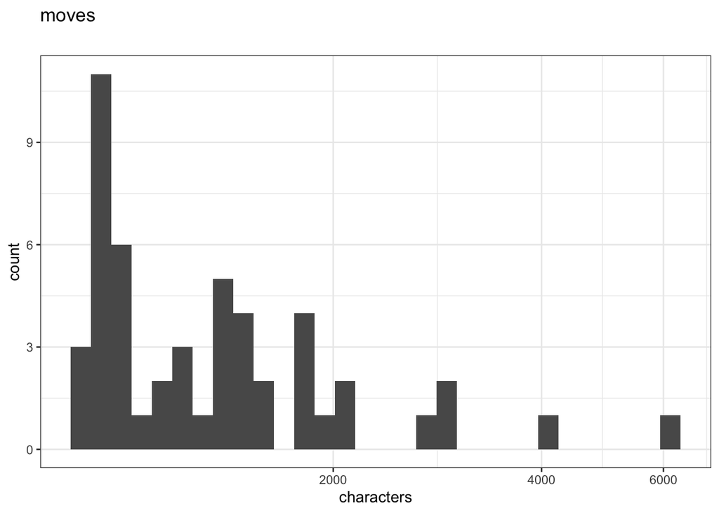

Distribution of values for moves

1150 missing values.

#### 1.1.17.2 Summary statistics

| name | data_type | n_missing | complete_rate | n_unique | empty | min | max | whitespace | label |
| --- | --- | --- | --- | --- | --- | --- | --- | --- | --- |
| moves | character | 1150 | 0.0416667 | 50 | 0 | 842 | 5990 | 0 | NA |

### 1.1.18 final_locations

#### 1.1.18.1 Distribution

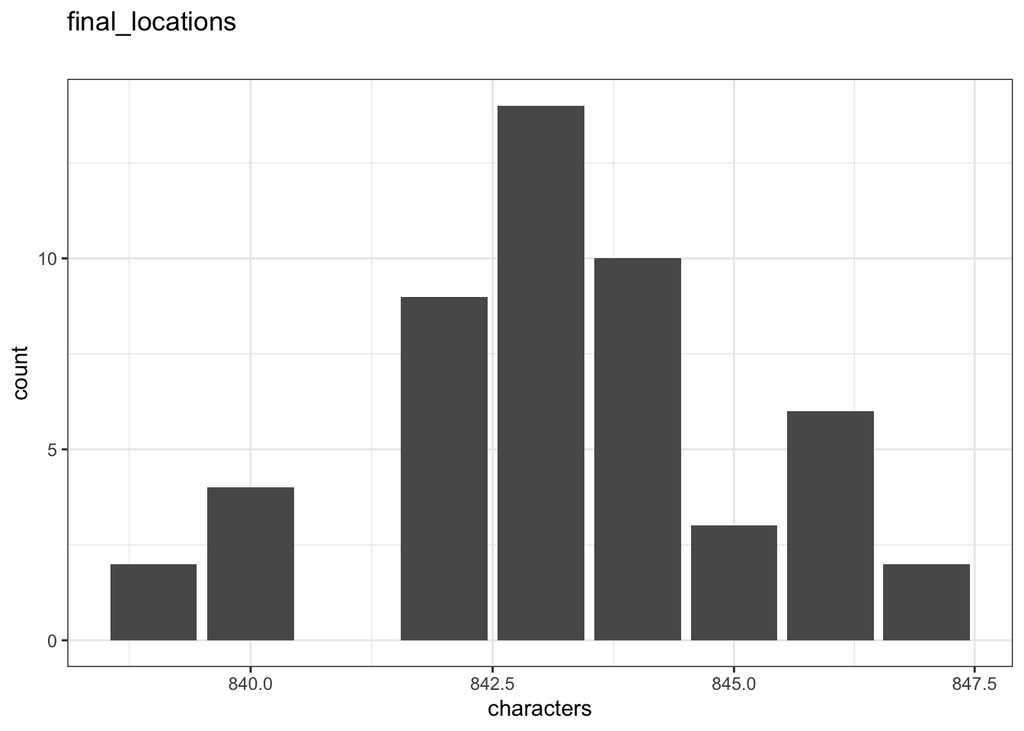

Distribution of values for final_locations

1150 missing values.

#### 1.1.18.2 Summary statistics

| name | data_type | n_missing | complete_rate | n_unique | empty | min | max | whitespace | label |
| --- | --- | --- | --- | --- | --- | --- | --- | --- | --- |
| final_locations | character | 1150 | 0.0416667 | 50 | 0 | 839 | 847 | 0 | NA |

### 1.1.19 0

#### 1.1.19.1 Distribution

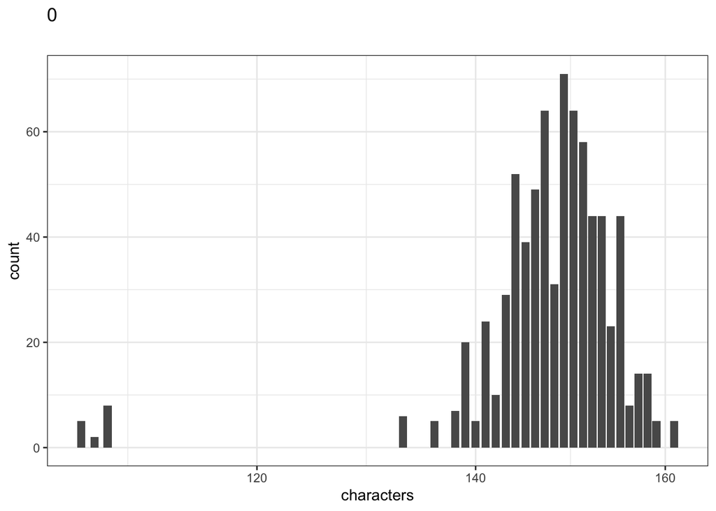

Distribution of values for 0

450 missing values.

#### 1.1.19.2 Summary statistics

| name | data_type | n_missing | complete_rate | n_unique | empty | min | max | whitespace | label |
| --- | --- | --- | --- | --- | --- | --- | --- | --- | --- |
| 0 | character | 450 | 0.625 | 217 | 0 | 106 | 161 | 0 | NA |

### 1.1.20 1

#### 1.1.20.1 Distribution

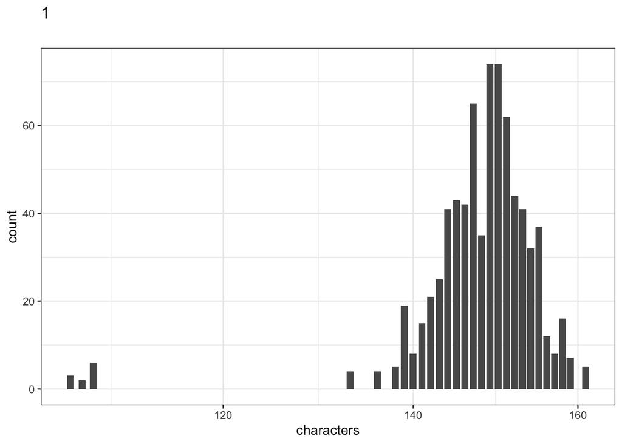

Distribution of values for 1

450 missing values.

#### 1.1.20.2 Summary statistics

| name | data_type | n_missing | complete_rate | n_unique | empty | min | max | whitespace | label |
| --- | --- | --- | --- | --- | --- | --- | --- | --- | --- |
| 1 | character | 450 | 0.625 | 220 | 0 | 106 | 161 | 0 | NA |

### 1.1.21 2

#### 1.1.21.1 Distribution

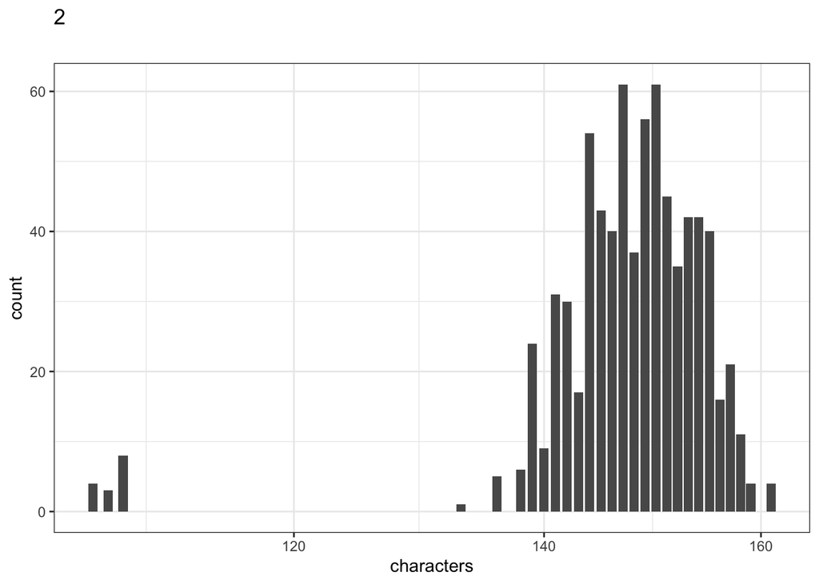

Distribution of values for 2

450 missing values.

#### 1.1.21.2 Summary statistics

| name | data_type | n_missing | complete_rate | n_unique | empty | min | max | whitespace | label |
| --- | --- | --- | --- | --- | --- | --- | --- | --- | --- |
| 2 | character | 450 | 0.625 | 218 | 0 | 106 | 161 | 0 | NA |

### 1.1.22 3

#### 1.1.22.1 Distribution

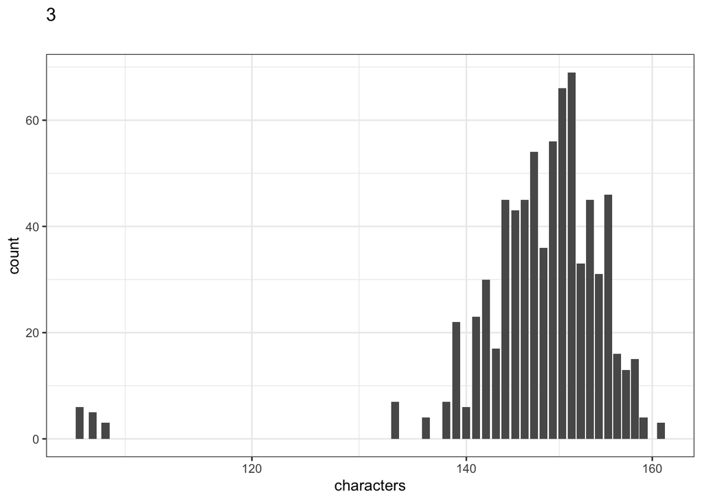

Distribution of values for 3

450 missing values.

#### 1.1.22.2 Summary statistics

| name | data_type | n_missing | complete_rate | n_unique | empty | min | max | whitespace | label |
| --- | --- | --- | --- | --- | --- | --- | --- | --- | --- |
| 3 | character | 450 | 0.625 | 219 | 0 | 106 | 161 | 0 | NA |

### 1.1.23 4

#### 1.1.23.1 Distribution

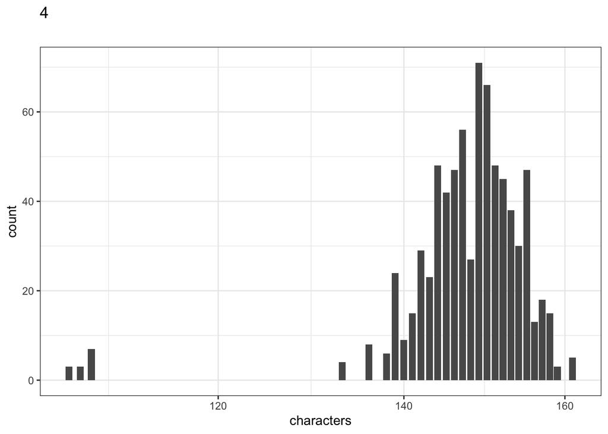

Distribution of values for 4

450 missing values.

#### 1.1.23.2 Summary statistics

| name | data_type | n_missing | complete_rate | n_unique | empty | min | max | whitespace | label |
| --- | --- | --- | --- | --- | --- | --- | --- | --- | --- |
| 4 | character | 450 | 0.625 | 221 | 0 | 106 | 161 | 0 | NA |

### 1.1.24 5

#### 1.1.24.1 Distribution

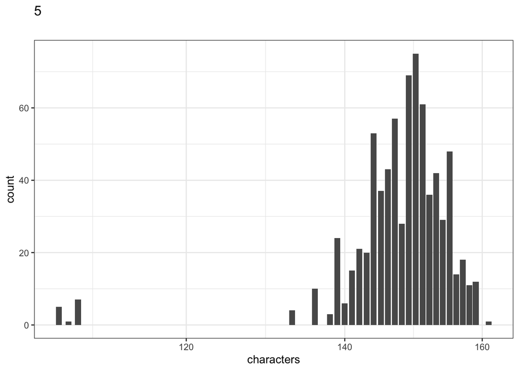

Distribution of values for 5

450 missing values.

#### 1.1.24.2 Summary statistics

| name | data_type | n_missing | complete_rate | n_unique | empty | min | max | whitespace | label |
| --- | --- | --- | --- | --- | --- | --- | --- | --- | --- |
| 5 | character | 450 | 0.625 | 226 | 0 | 106 | 161 | 0 | NA |

### 1.1.25 6

#### 1.1.25.1 Distribution

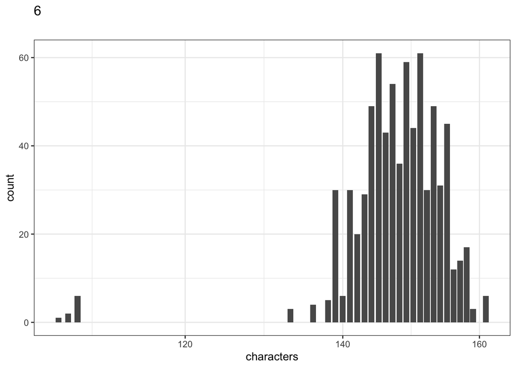

Distribution of values for 6

450 missing values.

#### 1.1.25.2 Summary statistics

| name | data_type | n_missing | complete_rate | n_unique | empty | min | max | whitespace | label |
| --- | --- | --- | --- | --- | --- | --- | --- | --- | --- |
| 6 | character | 450 | 0.625 | 221 | 0 | 106 | 161 | 0 | NA |

### 1.1.26 7

#### 1.1.26.1 Distribution

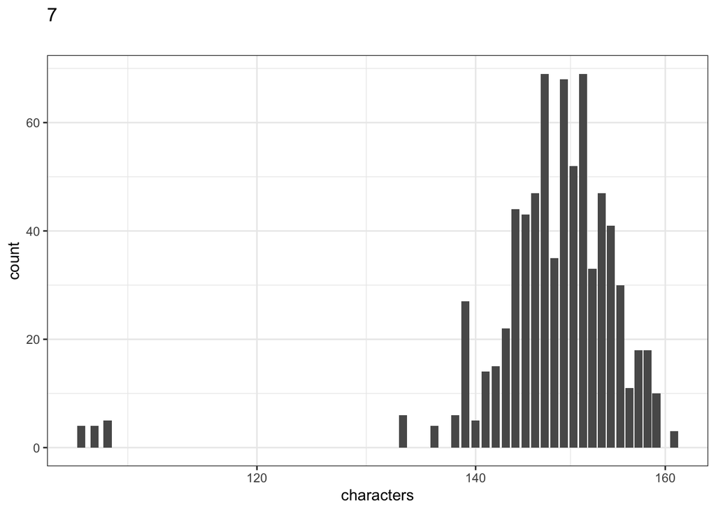

Distribution of values for 7

450 missing values.

#### 1.1.26.2 Summary statistics

| name | data_type | n_missing | complete_rate | n_unique | empty | min | max | whitespace | label |
| --- | --- | --- | --- | --- | --- | --- | --- | --- | --- |
| 7 | character | 450 | 0.625 | 223 | 0 | 106 | 161 | 0 | NA |

### 1.1.27 8

#### 1.1.27.1 Distribution

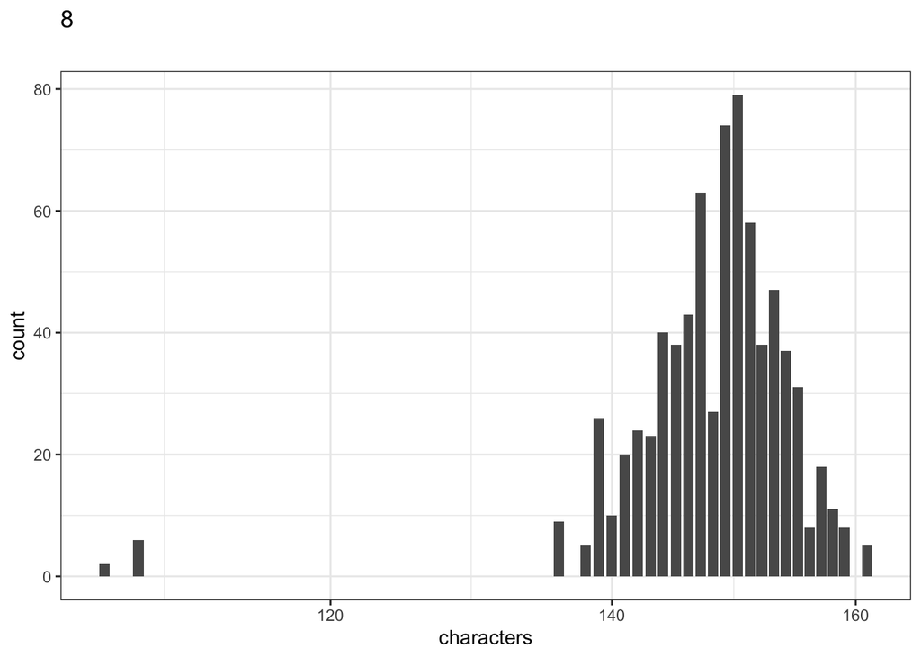

Distribution of values for 8

450 missing values.

#### 1.1.27.2 Summary statistics

| name | data_type | n_missing | complete_rate | n_unique | empty | min | max | whitespace | label |
| --- | --- | --- | --- | --- | --- | --- | --- | --- | --- |
| 8 | character | 450 | 0.625 | 219 | 0 | 106 | 161 | 0 | NA |

### 1.1.28 9

#### 1.1.28.1 Distribution

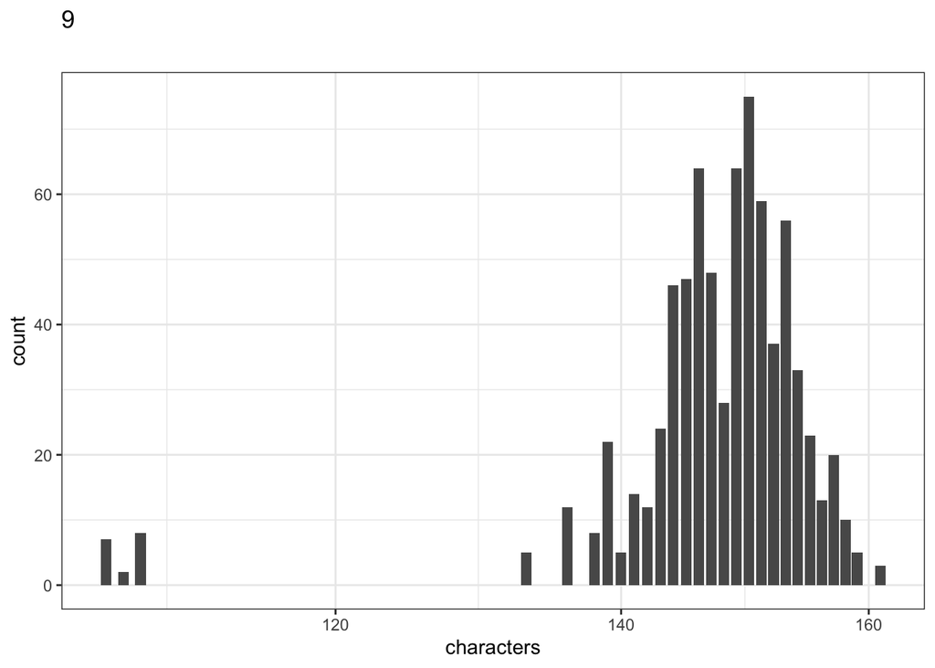

Distribution of values for 9

450 missing values.

#### 1.1.28.2 Summary statistics

| name | data_type | n_missing | complete_rate | n_unique | empty | min | max | whitespace | label |
| --- | --- | --- | --- | --- | --- | --- | --- | --- | --- |
| 9 | character | 450 | 0.625 | 223 | 0 | 106 | 161 | 0 | NA |

### 1.1.29 10

#### 1.1.29.1 Distribution

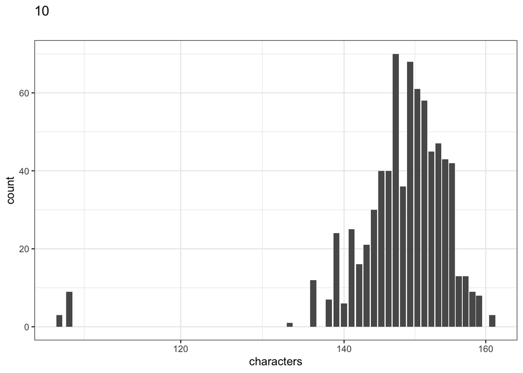

Distribution of values for 10

450 missing values.

#### 1.1.29.2 Summary statistics

| name | data_type | n_missing | complete_rate | n_unique | empty | min | max | whitespace | label |
| --- | --- | --- | --- | --- | --- | --- | --- | --- | --- |
| 10 | character | 450 | 0.625 | 217 | 0 | 107 | 161 | 0 | NA |

### 1.1.30 11

#### 1.1.30.1 Distribution

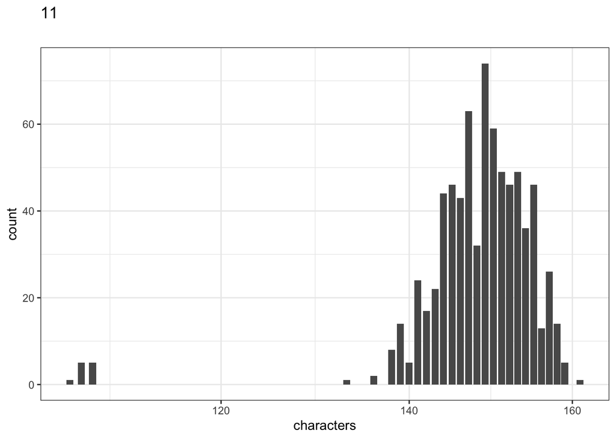

Distribution of values for 11

450 missing values.

#### 1.1.30.2 Summary statistics

| name | data_type | n_missing | complete_rate | n_unique | empty | min | max | whitespace | label |
| --- | --- | --- | --- | --- | --- | --- | --- | --- | --- |
| 11 | character | 450 | 0.625 | 222 | 0 | 106 | 161 | 0 | NA |

### 1.1.31 12

#### 1.1.31.1 Distribution

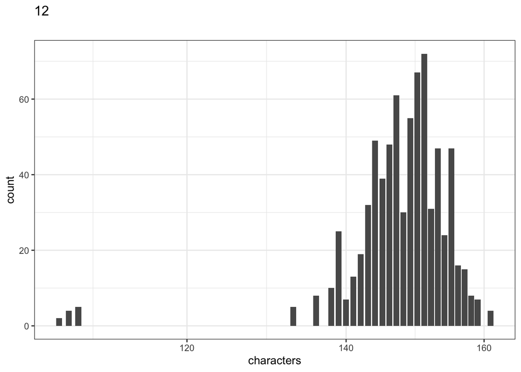

Distribution of values for 12

450 missing values.

#### 1.1.31.2 Summary statistics

| name | data_type | n_missing | complete_rate | n_unique | empty | min | max | whitespace | label |
| --- | --- | --- | --- | --- | --- | --- | --- | --- | --- |
| 12 | character | 450 | 0.625 | 219 | 0 | 106 | 161 | 0 | NA |

### 1.1.32 13

#### 1.1.32.1 Distribution

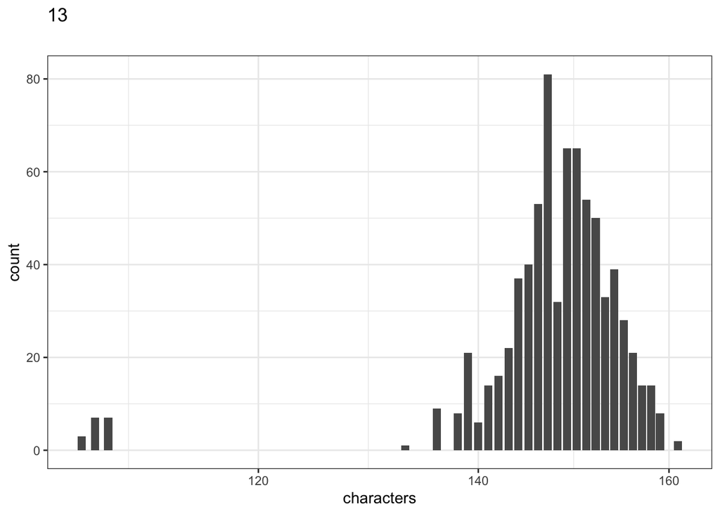

Distribution of values for 13

450 missing values.

#### 1.1.32.2 Summary statistics

| name | data_type | n_missing | complete_rate | n_unique | empty | min | max | whitespace | label |
| --- | --- | --- | --- | --- | --- | --- | --- | --- | --- |
| 13 | character | 450 | 0.625 | 215 | 0 | 106 | 161 | 0 | NA |

### 1.1.33 14

#### 1.1.33.1 Distribution

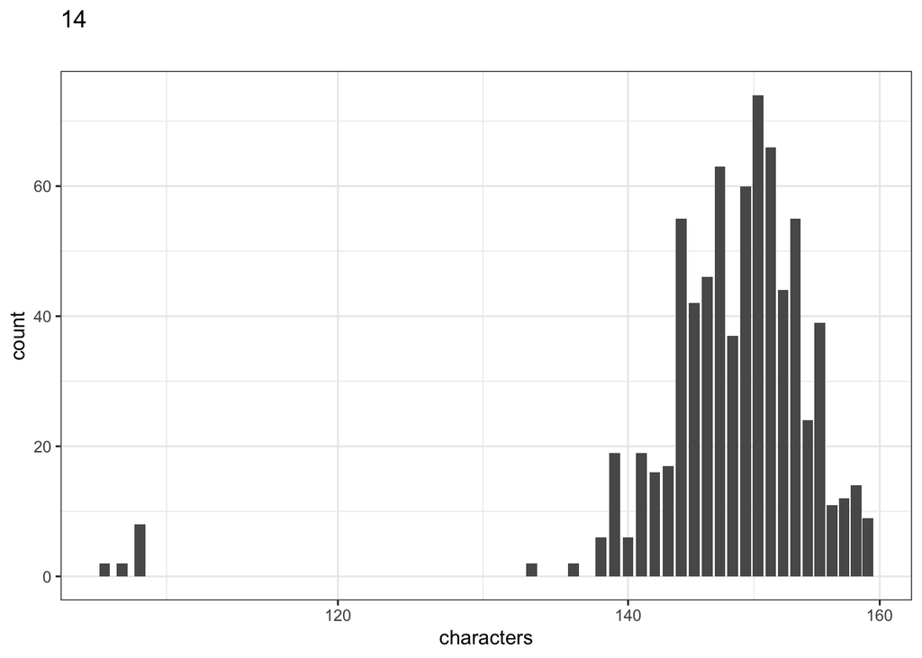

Distribution of values for 14

450 missing values.

#### 1.1.33.2 Summary statistics

| name | data_type | n_missing | complete_rate | n_unique | empty | min | max | whitespace | label |
| --- | --- | --- | --- | --- | --- | --- | --- | --- | --- |
| 14 | character | 450 | 0.625 | 219 | 0 | 106 | 159 | 0 | NA |

### 1.1.34 question_order

#### 1.1.34.1 Distribution

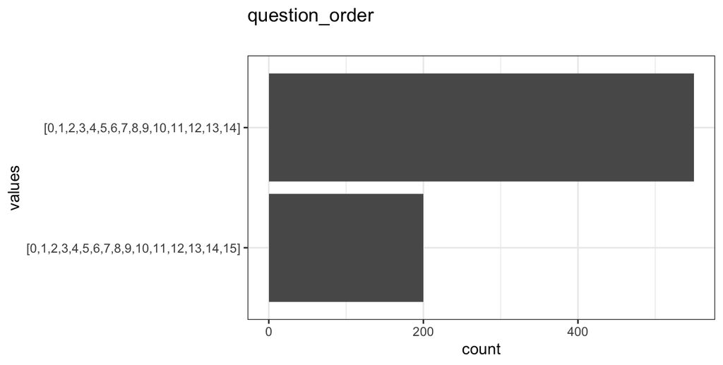

Distribution of values for question_order

450 missing values.

#### 1.1.34.2 Summary statistics

| name | data_type | n_missing | complete_rate | n_unique | empty | min | max | whitespace | label |
| --- | --- | --- | --- | --- | --- | --- | --- | --- | --- |
| question_order | character | 450 | 0.625 | 2 | 0 | 36 | 39 | 0 | NA |

### 1.1.35 15

#### 1.1.35.1 Distribution

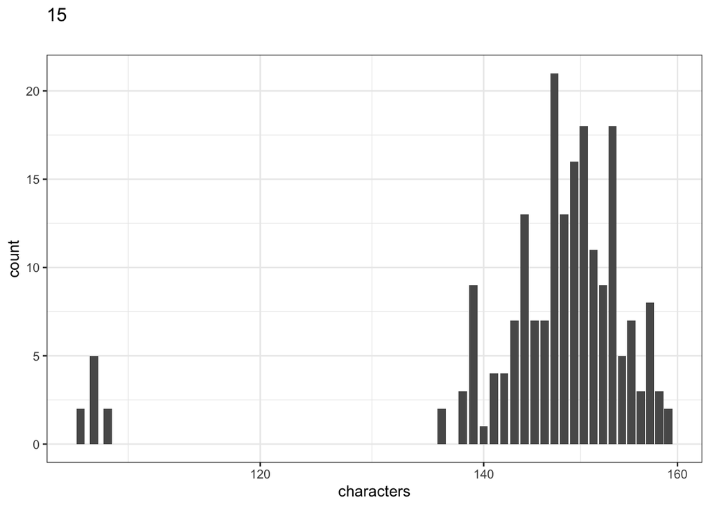

Distribution of values for 15

1000 missing values.

#### 1.1.35.2 Summary statistics

| name | data_type | n_missing | complete_rate | n_unique | empty | min | max | whitespace | label |
| --- | --- | --- | --- | --- | --- | --- | --- | --- | --- |
| 15 | character | 1000 | 0.1666667 | 131 | 0 | 106 | 159 | 0 | NA |

### 1.1.36 feedback

#### 1.1.36.1 Distribution

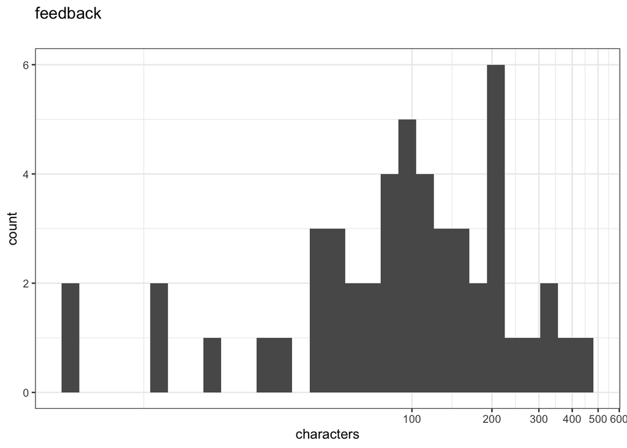

Distribution of values for feedback

1150 missing values.

#### 1.1.36.2 Summary statistics

| name | data_type | n_missing | complete_rate | n_unique | empty | min | max | whitespace | label |
| --- | --- | --- | --- | --- | --- | --- | --- | --- | --- |
| feedback | character | 1150 | 0.0416667 | 49 | 0 | 4 | 416 | 0 | NA |

### 1.1.37 age

#### 1.1.37.1 Distribution

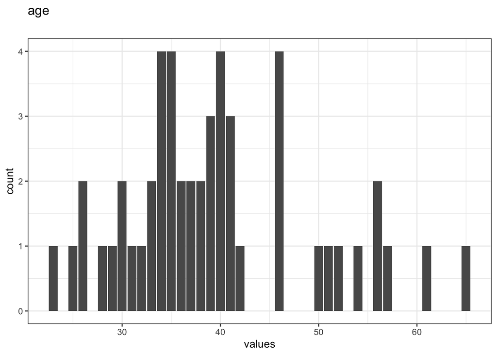

Distribution of values for age

1150 missing values.

#### 1.1.37.2 Summary statistics

| name | data_type | n_missing | complete_rate | min | median | max | mean | sd | hist | label |
| --- | --- | --- | --- | --- | --- | --- | --- | --- | --- | --- |
| age | numeric | 1150 | 0.0416667 | 23 | 38 | 65 | 39.44 | 9.564304 | ▃▇▅▂▁ | NA |

### 1.1.38 ethnicity

#### 1.1.38.1 Distribution

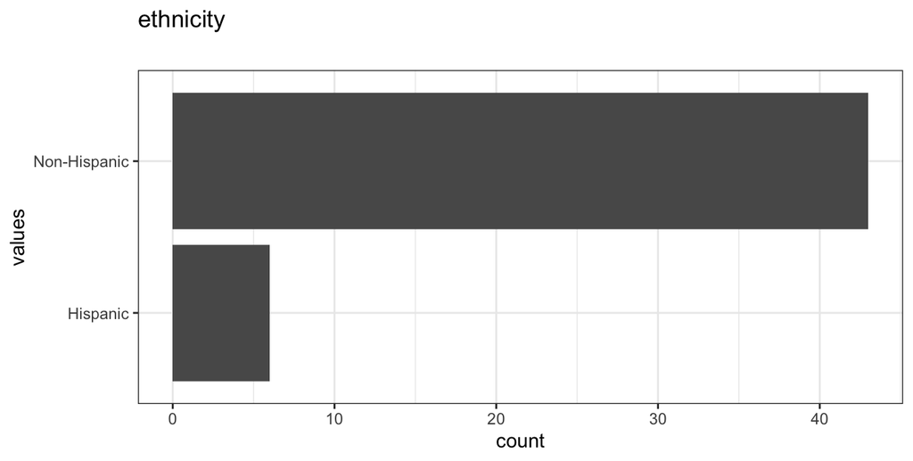

Distribution of values for ethnicity

1151 missing values.

#### 1.1.38.2 Summary statistics

| name | data_type | n_missing | complete_rate | n_unique | empty | min | max | whitespace | label |
| --- | --- | --- | --- | --- | --- | --- | --- | --- | --- |
| ethnicity | character | 1151 | 0.0408333 | 2 | 0 | 8 | 12 | 0 | NA |

### 1.1.39 gender

#### 1.1.39.1 Distribution

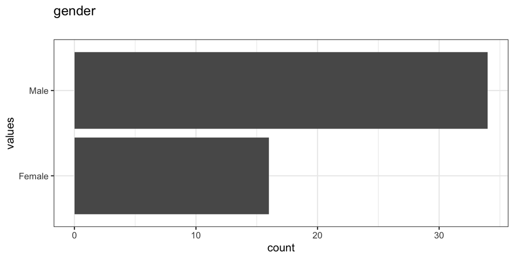

Distribution of values for gender

1150 missing values.

#### 1.1.39.2 Summary statistics

| name | data_type | n_missing | complete_rate | n_unique | empty | min | max | whitespace | label |
| --- | --- | --- | --- | --- | --- | --- | --- | --- | --- |
| gender | character | 1150 | 0.0416667 | 2 | 0 | 4 | 6 | 0 | NA |

### 1.1.40 race

#### 1.1.40.1 Distribution

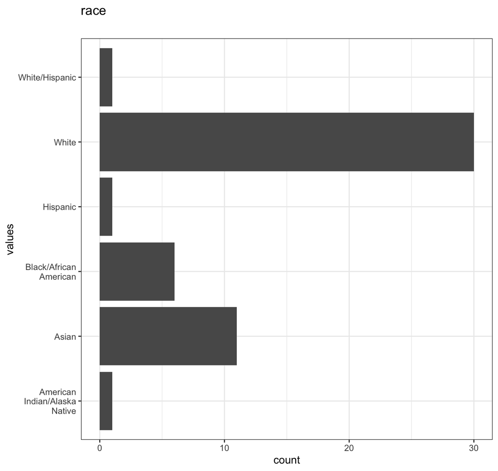

Distribution of values for race

1150 missing values.

#### 1.1.40.2 Summary statistics

| name | data_type | n_missing | complete_rate | n_unique | empty | min | max | whitespace | label |
| --- | --- | --- | --- | --- | --- | --- | --- | --- | --- |
| race | character | 1150 | 0.0416667 | 6 | 0 | 5 | 29 | 0 | NA |

## 1.2 Missingness report

| description | rt | response | 0 | 1 | 2 | 3 | 4 | 5 | 6 | 7 | 8 | 9 | 10 | 11 | 12 | 13 | 14 | question_order | view_history | 15 | trial_id | stimulus | success | timeout | failed_images | failed_audio | failed_video | init_locations | moves | … |
| --- | --- | --- | --- | --- | --- | --- | --- | --- | --- | --- | --- | --- | --- | --- | --- | --- | --- | --- | --- | --- | --- | --- | --- | --- | --- | --- | --- | --- | --- | --- |
| Missing values per variable | 50 | 300 | 450 | 450 | 450 | 450 | 450 | 450 | 450 | 450 | 450 | 450 | 450 | 450 | 450 | 450 | 450 | 450 | 1000 | 1000 | 1050 | 1100 | 1150 | 1150 | 1150 | 1150 | 1150 | 1150 | 1150 | … |
| Missing values in 17 variables | 1 | 1 | 1 | 1 | 1 | 1 | 1 | 1 | 1 | 1 | 1 | 1 | 1 | 1 | 1 | 1 | 1 | 1 | 0 | 0 | 0 | 0 | 0 | 0 | 0 | 0 | 0 | 0 | 0 | … |
| Missing values in 16 variables | 1 | 1 | 1 | 1 | 1 | 1 | 1 | 1 | 1 | 1 | 1 | 1 | 1 | 1 | 1 | 1 | 1 | 1 | 0 | 1 | 0 | 0 | 0 | 0 | 0 | 0 | 0 | 0 | 0 | … |
| Missing values in 33 variables | 1 | 0 | 0 | 0 | 0 | 0 | 0 | 0 | 0 | 0 | 0 | 0 | 0 | 0 | 0 | 0 | 0 | 0 | 1 | 0 | 0 | 0 | 0 | 0 | 0 | 0 | 0 | 0 | 0 | … |
| Missing values in 31 variables | 1 | 1 | 0 | 0 | 0 | 0 | 0 | 0 | 0 | 0 | 0 | 0 | 0 | 0 | 0 | 0 | 0 | 0 | 0 | 0 | 1 | 1 | 0 | 0 | 0 | 0 | 0 | 0 | 0 | … |
| Missing values in 31 variables | 1 | 0 | 0 | 0 | 0 | 0 | 0 | 0 | 0 | 0 | 0 | 0 | 0 | 0 | 0 | 0 | 0 | 0 | 0 | 0 | 0 | 0 | 0 | 0 | 0 | 0 | 0 | 1 | 1 | … |
| Missing values in 30 variables | 0 | 0 | 0 | 0 | 0 | 0 | 0 | 0 | 0 | 0 | 0 | 0 | 0 | 0 | 0 | 0 | 0 | 0 | 0 | 0 | 0 | 0 | 1 | 1 | 1 | 1 | 1 | 0 | 0 | … |
| Missing values in 27 variables | 1 | 1 | 0 | 0 | 0 | 0 | 0 | 0 | 0 | 0 | 0 | 0 | 0 | 0 | 0 | 0 | 0 | 0 | 0 | 0 | 1 | 0 | 0 | 0 | 0 | 0 | 0 | 0 | 0 | … |
| 1 other, less frequent patterns | 1 | 1 | 0 | 0 | 0 | 0 | 0 | 0 | 0 | 0 | 0 | 0 | 0 | 0 | 0 | 0 | 0 | 0 | 0 | 0 | 1 | 0 | 0 | 0 | 0 | 0 | 0 | 0 | 0 | … |